# Lab 10 - Confidence Intervals

Carl Gladish

Nov 11, 2025

This lab contains some instructional material along with some questions. You are required to submit your answers in a Microsoft Word report produced by “knitting” an R Notebook to .docx format. Your Word file will contain *all* your R code *and* your written answers and charts.

This week, start by creating your own R Markdown file (i.e., R notebook) called Lab_10_Notebook.Rmd.

**Due date: 11:59pm, two school days from today (weekend days count as half)**

## Lab Objectives

The purpose of this lab is to:

- Calculate confidence intervals for a population mean $\mu$ using *small* samples ($n<30$).
- Understand what increasing the sample size $n$ or decreasing the confidence level $(1-\alpha)$ does to the width of the confidence interval.
- Automate generating text that interprets the resulting intervals.

## Calculating Confidence Intervals Using Small Samples

Load the `mosaicData` library and import the `TenMileRace` dataset.

```r
library(mosaic)
data(TenMileRace)
```

We will be working with the variable $X=$ `TenMileRace$net`, which is the *net* time that a runner took to complete the 10 mile running race. In this case, we have the entire set of population data, so we can calculate the population mean, $μ$.

```r
mean(TenMileRace$net)
```

```
## [1] 5599.065
```

The mean time was $\mu=5599.1$ seconds (93 minutes and 19.1 seconds). Even though we know $\mu$ exactly, we will be constructing confidence intervals as if we do *not* know $\mu$ using samples drawn with this population. The purpose here is not to be realistic, but rather to help you understand how confidence intervals work.

If we take a sample of size $n$, then the confidence interval for $\mu$ at confidence level $1-\alpha$ is:
$$\overline{X}-t_{\alpha/2}\cdot\frac{s}{\sqrt{n}}
< \mu <
\overline{X}+t_{\alpha/2}\cdot\frac{s}{\sqrt{n}}$$

In this formula

- $n=$ sample size
- $\overline{X}=$ sample mean
- $s=$ sample standard deviation
- $t_{\alpha/2}=$ the value of $t$ ($\textrm{df}=n-1$) with area $\alpha/2$ to its *right*

This formula works as long as:

- $X$ is a normally distributed variable, or
- $n \geq 30$

The variable `net` is normally distributed (see QQ plot below) except for some mild positive skewness, so the above formula is valid for any $n$.

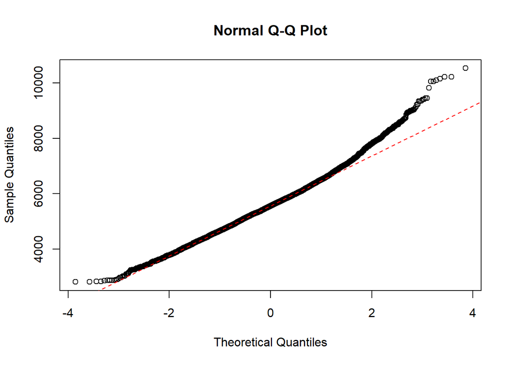

```r
qqnorm( TenMileRace$net)
qqline( TenMileRace$net, lty="dashed", col="red")
```

To begin, we will use a sample size $n=15$. Select a random sample of $15$ net times:

```r
n.sample <- 15
racetimes.sample <- sample(TenMileRace$net, n.sample)
```

The R function `t.test` allows us to construct confidence intervals with one R expression. (Note that your result will vary since the sample is random.)

```r
t.test(racetimes.sample)
```

```
##
##  One Sample t-test
##
## data:  racetimes.sample
## t = 25.855, df = 14, p-value = 3.231e-13
## alternative hypothesis: true mean is not equal to 0
## 95 percent confidence interval:
##  5511.926 6509.140
## sample estimates:
## mean of x
##  6010.533
```

There is a lot of information here that we are not interested in at the moment. To pull out just the lower and upper limits of the confidence interval, use

```r
conf.int <- t.test(racetimes.sample)$conf.int
lim.low  <- round(conf.int[[1]], 1)
lim.high <- round(conf.int[[2]], 1)
```

An appropriate conclusion is:

“The population mean $\mu$ for variable `net` is between 5511.9 and 6509.1 seconds, with 95% confidence.”

Is the actual population mean $\mu$ in this interval? For this particular random sample, $\mu=5599.1$ is inside the interval $(5511.9, 6509.1)$.

In theory, if we repeated this procedure many times, the resulting interval would contain $\mu$ about 19 times out of 20 (95% of the time). About 5% of the time the interval will *miss* $\mu$.

### Question 1

#### Q1a

Generate a random sample of size $n=20$ from the `TenMileRace` data frame for variable `net`.

Using this random sample, generate a confidence interval for $\mu$ at each of the following confidence levels:

- 95%
- 90%
- 75%

What happens to the width of the confidence interval as the confidence level decreases?

#### Q1b

Now create 100 random samples of size $n=20$ from the `TenMileRace` data frame for variable `net`.

For each sample, create a 95% confidence interval for that sample and check whether the actual $\mu$ lies within the interval or not.

Print a frequency table showing the number of times $\mu$ is in the confidence interval or not. (It will have a form like the table shown below.)

```
## in.interval
## FALSE  TRUE
##     4    96
```

### Question 2

Now you will need to calculate confidence intervals for the mean $\mu$ of `net` using the formula

$$\overline{X}-t_{\alpha/2}\cdot\frac{s}{\sqrt{n}}
< \mu <
\overline{X}+t_{\alpha/2}\cdot\frac{s}{\sqrt{n}}$$

For each sample size in this list:

- $n=50$
- $n=100$
- $n=150$

calculate a 95% confidence interval based on the above formula. Use R to calculate the sample statistics $\overline{X}$ and $s$ but do not use `t.test`.

For each $n$, record the write a one sentence conclusion regarding $\mu$.

Finally, write a sentence to observe how the confidence interval widths change as $n$ increases.

### Question 3

Now load the `cats` data frame, which is part of the `MASS` library.

```r
library(MASS)
data(cats)
```

#### Q3a

Find 95% confidence intervals for:

- body weight of female cats
- body weight of male cats
- heart weight of female cats
- heart weight of male cats

Note that these samples are large enough that we don’t have to worry about whether they are normally distributed. For each interval, write a one-sentence conclusion.

#### Q3b

Based on your four intervals, does there appear to be a significant difference between the heart weights of male cats versus female cats? How about body weights?

### Question 4 - Automating the Interpretation Step

You may have noticed that when we printed a confidence interval, the confidence level 95% was included as an attribute in the output:

```r
t.test(filter(cats, Sex=="F")$Bwt, conf.level=0.95)$conf.int
```

```
## [1] 2.279129 2.440020
## attr(,"conf.level")
## [1] 0.95
```

We can extract this attribute using:

```r
attr( t.test(filter(cats, Sex=="F")$Bwt, conf.level=0.95)$conf.int, "conf.level")
```

```
## [1] 0.95
```

Now let’s put that together:

```r
c.int <- t.test( filter(cats, Sex=="F")$Bwt, conf.level=0.95)$conf.int

lim.low <- round(c.int[[1]], 2)
lim.high <- round(c.int[[2]], 2)
conf.level <- attr( c.int, "conf.level")

cat(paste0("We are ", 100*conf.level, "% confident that the mean body weight of female cats is between ", lim.low, " and ", lim.high," kilograms."))
```

```
## We are 95% confident that the mean body weight of female cats is between 2.28 and 2.44 kilograms.
```

#### Q4a

Write a function `interpret.conf.int` that takes inputs:

- `data` (a vector of sample data),
- `var` (variable name),
- `unit` (variable units), and
- `conf.level` (confidence level).

The function returns a string containing an appropriate one-sentence conclusion containing the confidence interval (as in the previous example) and confidence level. Use `t.test` if you like. If the user does not specify a confidence level, a default of $0.95$ must be applied.

Apply your function `interpret.conf.int` to the remaining three cases (female heart, male body, male heart) not given above. Use 99% confidence for one case and omit the confidence level for one case.